# Bubblemaps v1.0

Giuseppe D’Agostino

[Back to the index page.](https://gdagstn.github.io)  
This is an R base graphics implementation of a bubblechart arranged as a heatmap, i.e. with rows and columns arranged by hiearchical clustering. It is currently used to map numerical values (such as correlation) to colours, and a second set of numerical values (assumed to be p-values, thus log-transformed and filtered for significance) to dot size.

```r
require(viridis)
```

```r
require(pheatmap)
```

Let’s simulate a correlation matrix by taking values from a random uniform distribution between -0.8 and 0.8.

```r
cors = data.frame(matrix(runif(n = 100, min = -0.8, max = 0.8), nrow = 10, ncol = 10))
```

We now simulate associated p-values. To do this we will first simulate a uniform distribution, then “spike in” some low p-values for high absolute correlations ( > 0.55).

```r
pvals = matrix(runif(n = 100, min = 0, max = 1), nrow = 10, ncol = 10)
pvals[which(abs(cors) > 0.55)] = runif(n = length(which(abs(cors) > 0.55)), min = 1e-05, max = 1e-03)
pvals = as.data.frame(pvals, stringsAsFactors = F)
```

Let’s look at the p value distribution to make sure it looks like a nice enough result, worth plotting

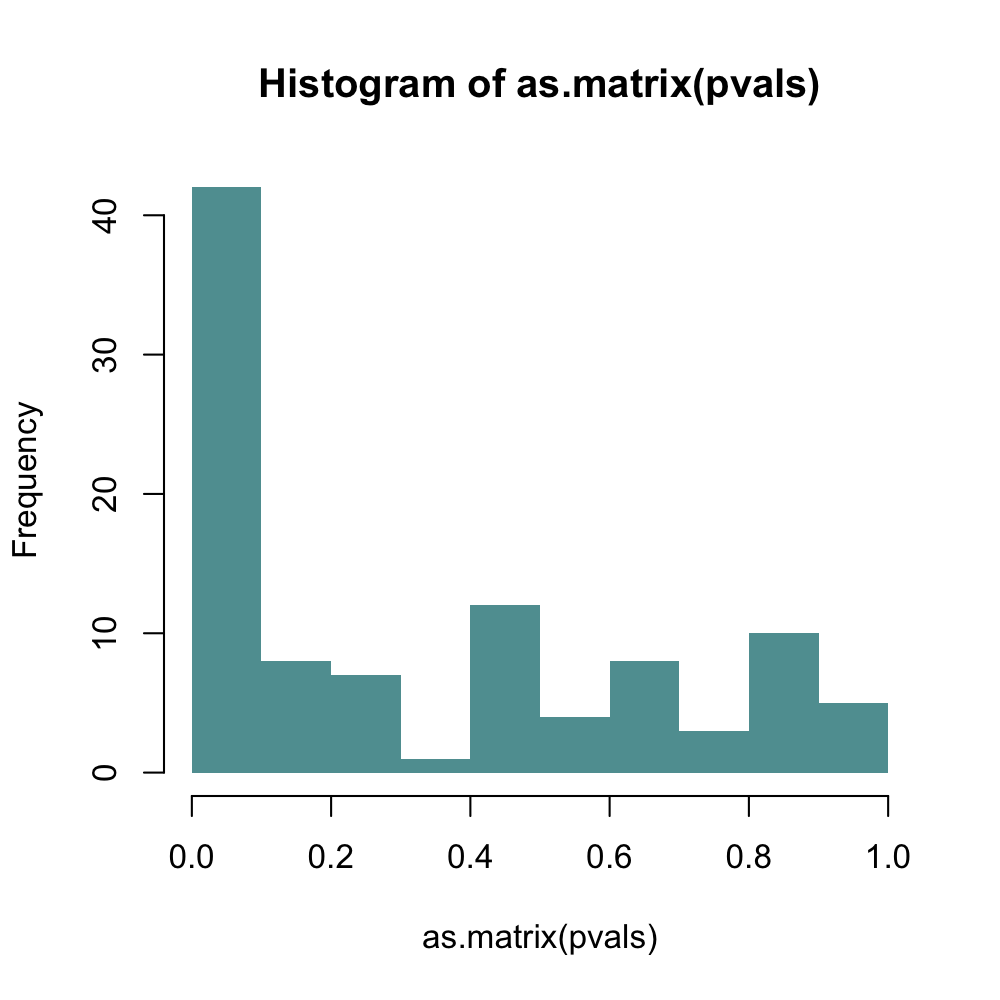

```r
hist(as.matrix(pvals), breaks = 10, col = "cadetblue", border = NA)
```

We first define a function, `makeGrid`, that draws a blank canvas with the size we need. It is a grid of x by y that will be populated by another function

```r
#' Grid canvas
#' @param ys numeric, number of rows in the grid
#' @param xs numeric, number of columns in the grid
#' @param ... passed to plot and points
#' @return an empty canvas with ys and xs rows and columns

makeGrid = function(ys, xs, ...)
{
    plot(y = 1:ys, x = rep(1, ys), xlim = c(1,xs), ...)
    for(i in 2:xs) points(y = 1:ys, x = rep(i,ys), ...)
}
```

We then define another function, `prop_cex` that maps dot sizes to values (cex). This function takes as arguments the values, bins (number of different dot sizes), a minimum (minc) and a maximum (maxc) dot size, a value with which NA values are replaced (na.value) and a value with which infinite values are replaced (inf.value)

```r
#' Grid canvas
#' @param values vector of numeric values to be mapped to dot sizes
#' @param bins numeric, number of dot sizes in which the values are binned
#' @param minc numeric, smallest dot size
#' @param maxc numeric, largest dot size
#' @param na.value numeric, value with which NAs will be replaced in the values vector
#' @param inf.value numeric, value with which Inf will be replaced in the values vector
#' @return a vector of binned dot sizes mapped to the values

prop_cex <- function(values, bins, minc = 0.3, maxc = 3, na.value = 0, inf.value = 400)
{
    values[is.na(values)] = na.value
    values[!is.finite(values)] = inf.value

    ordered.values <- values[order(values, decreasing = T)]

    cex.values <- seq(minc, maxc, length.out = length(unique(values)))
    cex.frame <- as.data.frame(cbind(cex.values, lfc =rev(unique(ordered.values))))
    cex.binned <- seq(minc, maxc, length.out = bins)
    outdf <- as.data.frame(values)
    outdf$cex.values = sapply(outdf$values, function (x) cex.frame[which(cex.frame$lfc == x),1])
    cex.values.binned = as.data.frame(sapply(outdf$cex.values, function(x) cut(x, breaks = cex.binned, include.lowest = T, labels = cex.binned[1:length(cex.binned)-1] )), stringsAsFactors = F)
    outdf$binned = as.numeric(levels(cex.values.binned[,1])[cex.values.binned[,1]])
    return(outdf$binned)
}
```

The third function we need to define maps colors to values, and is directly taken by the `pheatmap` package. It takes as arguments the values and the color palette of choice.

```r
#' Color key
#' @param values vector of numeric values to be mapped to colors
#' @param pal vector of characters indicating colors
#' @return a vector of colors mapped to values

colorKey <- function(values, pal = viridis(25, option = "B"))
{
    require(pheatmap)
    values_sc <- scale(values)
    bks <- pheatmap:::generate_breaks(values_sc, length(pal), center = F)
    cols <- pheatmap:::scale_colours(values_sc, col=pal, breaks=bks, na_col = "gray")
    cols <- as.character(cols)
    return(cols)
}
```

Finally, we define the actual `bubbleMap` function. Having defined all the other parts separately, it is trivial to plot the dots with their respective colors and sizes in the grid drawn by `makeGrid`. This function takes as arguments the data frame of values, the data frame of p values, the number of dot size bins (passed to `prop_cex`), the color palette (passed to `colorKey`), the map title (maplabel passed in “main” to the plot function). sp is a spacer used to draw the color key properly. Notice that the way dots are ordered comes from the `pheatmap` clustering. This is a hack that will be improved on in the future.

```r
#' Bubble map
#' @param valuedf data frame with numerics that will be mapped to colors
#' @param pvaluedf data frame with numerics that will be mapped to dot sizes. treated as a p-value data frame (values < 0.05 are filtered)
#' @param cbins numeric, passed to bins in prop_cex
#' @param color_pal vector of characters indicating colors to be mapped
#' @param maplabel character passed to main in the plot
#' @param ... other arguments passed to plot()
#' @return a pretty bubble map



bubbleMap <- function(valuedf, pvaluedf, cbins = 5, color_pal = colorRampPalette(c("slateblue", "gray", "orange"))(25), maplabel =
    "Correlation", ...)
{

    pmap <- pheatmap(valuedf, silent = T)
    valuedf <- as.data.frame(valuedf[rev(pmap$tree_row$order), pmap$tree_col$order])
    pvaluedf <-  as.data.frame(pvaluedf[rev(pmap$tree_row$order), pmap$tree_col$order])

    #pvaluedf$id = rownames(pvaluedf)
    p2 = as.data.frame(t(pvaluedf))
    p2$func = rownames(p2)
    moltenp = reshape::melt.data.frame(p2)

    moltenp$logP = as.numeric(-log10(moltenp$value))
    moltenp$logP[moltenp$logP < 1.3] = 1
    moltenp$cexes = prop_cex(moltenp$logP, bins = cbins, minc = 1, maxc = 4.4)
    moltenp$cexes[moltenp$logP == 1] = 0.5

    pcex = as.data.frame(cbind(10^-moltenp$logP, moltenp$cexes))
    pcex = pcex[order(pcex[,1]),]
    colnames(pcex) = c("logP", "cexes")

    edgen = round(max(c(abs(min(as.numeric(unlist(valuedf)))), abs(max(as.numeric(unlist(valuedf)))))), digits = 1)

    c2 = as.data.frame(t(valuedf))
    c2$func = rownames(c2)
    moltenc = reshape::melt.data.frame(c2)
    colors = colorKey(values = c(- edgen, edgen, moltenc$value), pal = color_pal)
    colors = colors[3:length(colors)]
    moltenp$colors = colors

    nr = nrow(valuedf)
    nc = ncol(valuedf)
    xsc = (1:nc)/nc
    ysc = (1:nr)/nr

    coordf = expand.grid(1:length(unique(moltenp$func)), 1:length(unique(moltenp$variable)))
    par(mar=c(10,0,3,6))
    plot(coordf$Var1/max(coordf$Var1), coordf$Var2/max(coordf$Var2), cex = 0, bty = "n", xaxt = "n", yaxt = "n", xlab = NA, ylab = NA, ylim = c(0,1.45), xlim = c(-0.1, 1.1), ...)
    #abline(h = coordf$Var2)
    points(coordf$Var1/max(coordf$Var1), coordf$Var2/max(coordf$Var2), cex = moltenp$cexes, col = moltenp$colors, pch = 16, bty = 'n')
    axis(1, at = unique(coordf$Var1)/max(coordf$Var1), labels = colnames(valuedf) , las = 2, cex.axis = 0.9)
    axis(4, at = unique(coordf$Var2)/max(coordf$Var2), labels = rownames(valuedf), las = 2, cex.axis = 0.7)


    rect_series = seq(0.05, 0.4, length.out = length(color_pal) + 1)

    for(q in 1:length(color_pal))
        {
            rect(xleft = rect_series[q], ybottom = 1.2, xright = rect_series[q+1], ytop = 1.25, col = color_pal[q], border = NA)
        }

    rect(xleft = 0.05, xright = 0.4, ybottom = 1.2 ,ytop = 1.25)

    text(x = 0.05, y = 1.3, labels = paste("-", edgen))
    text(x = 0.4, y = 1.3, labels = edgen)
    text(x = 0.225, y = 1.28, pos = 3, labels = maplabel)


    cvec = vector()
    for(i in 1:length(unique(moltenp$cexes)))
    {
        cvec[i] <- pcex[which(pcex$cexes == unique(pcex$cexes)[i])[length(which(pcex$cexes == unique(pcex$cexes)[i]))],1]
    }
    cvec = cvec[1:(length(cvec)-1)]
    cxvec = c("p > 0.05", paste("p <=", rev(formatC(cvec, format = "e", digits = 2))))


    point_series = seq(0.6, 1, length.out = length(unique(moltenp$cex)))

    for(i in 1:length(point_series)) points(y = 1.25, x = point_series[i], cex = unique(moltenp$cex)[order(unique(moltenp$cex))][i], pch = 16, col = "gray")

    text(x = point_series, y = rep(1.3, length(point_series)), labels = cxvec, cex = 0.7, srt = 45, pos = 4)

}
```

Let’s now apply the function to our simulated correlations and p values:

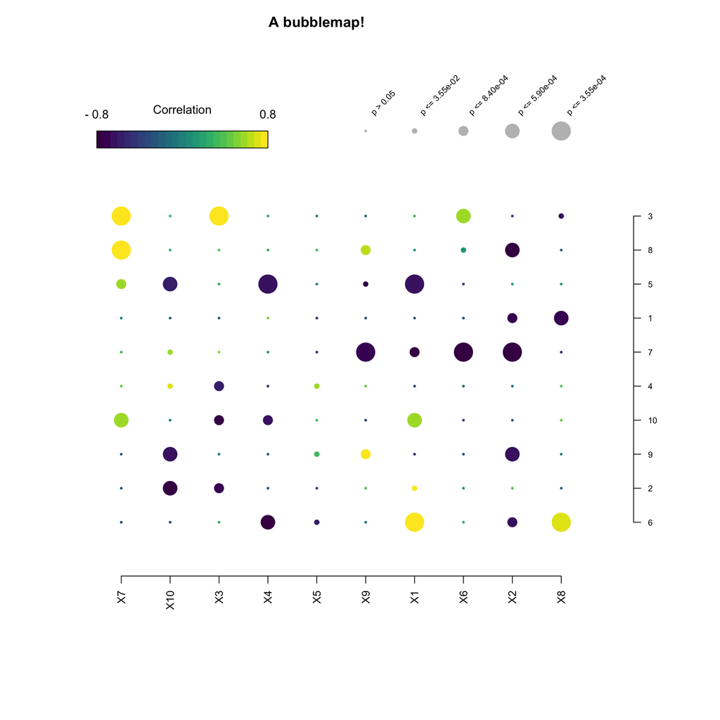

```r
bubbleMap(cors, pvals, color_pal = viridis(25, option = "D"), main = "A bubblemap!")
```

Back to top  
[Back to the index page.](https://gdagstn.github.io)